# Two Variables: Quantitative and Qualitative

Author

Lorenzo D. Babato

Published

November 14, 2026

# The Data

```r
# install packages: install.packages("package")
# load packages
library(tidyverse)
library(knitr)
library(gtsummary)
library(ggstatsplot)
library(downlit)
library(broom)
library(car)
library(here)
```

```r
# load the data
df <- read_csv(here("data", "my_dataset_enso.csv"))

df <- df |>
  mutate(
    Academic_Satisfaction = factor(
      Academic_Satisfaction,
      levels = c("Low_satisfaction", "Moderate_Satisfaction", "High_Satisfaction"),
      ordered = TRUE
    ),
    study_hours_num = case_when(
      Sleep_Duration == "Less_than_6_hours" ~ 5.0,
      Sleep_Duration == "6_to_8_hours" ~ 7.0,
      Sleep_Duration == "More_than_8_hours" ~ 9.0,
      TRUE ~ 6.0
    )
  ) |>
  select(
    study_hours_num,
    Academic_Satisfaction
  )
```

The NVSU_Student_Survey data set is a data frame with 68 rows and 2 main variables.

- `study_hours_num`: Estimated study/sleep hours derived from sleep duration (numeric representation).
- `Academic_Satisfaction`: Low_satisfaction, Moderate_Satisfaction, High_Satisfaction.

This data set provides information on student profiles and satisfaction levels at Nueva Vizcaya State University (NVSU). The first 6 rows of the data set are shown in Table 1.

```r
df |>
  head() |>
  (\(x) kable(x, col.names = c("Study Hours (Numeric)",
                               "Academic Satisfaction")
              )
   )()
```

Table 1: The first 6 observations of the data set.

| Study Hours (Numeric) | Academic Satisfaction |
| --- | --- |
| 5 | Low_satisfaction |
| 5 | Low_satisfaction |
| 5 | Low_satisfaction |
| 5 | Low_satisfaction |
| 5 | Low_satisfaction |
| 5 | Low_satisfaction |

## Descriptive Statistics

The summary statistics of study_hours_num when grouped according to Academic_Satisfaction are shown in Table 2.

```r
df |>
  group_by(Academic_Satisfaction) |>
  summarise(
    Mean = round(mean(study_hours_num, na.rm = TRUE), 2),
    SD = round(sd(study_hours_num, na.rm = TRUE), 2),
    Min = min(study_hours_num, na.rm = TRUE),
    Max = max(study_hours_num, na.rm = TRUE),
    N = n()
  ) |>
  kable(col.names = c("Academic Satisfaction", "Mean", "SD", "Min", "Max", "N"))
```

Table 2: Summary statistics of Study Hours grouped by Academic Satisfaction.

| Academic Satisfaction | Mean | SD | Min | Max | N |
| --- | --- | --- | --- | --- | --- |
| Low_satisfaction | 5.00 | 0.00 | 5 | 5 | 11 |
| Moderate_Satisfaction | 6.21 | 0.99 | 5 | 7 | 43 |
| High_Satisfaction | 7.71 | 0.99 | 7 | 9 | 14 |

# Hypothesis Testing

## Research Question

Do students with varying levels of academic satisfaction differ significantly in their estimated study/sleep hours?

## Hypothesis and Test Statistics

- $H_0:$ The distribution of study/sleep hours is identical across academic satisfaction groups.
- $H_a:$ Study/sleep hours differ significantly between academic satisfaction groups.
- Significance level, $\alpha=5\%\,\text{or p-value}\,\le\,.05$.
- **Kruskal-Wallis test** (non-parametric numerical-categorical test).

```r
car::leveneTest(study_hours_num ~ Academic_Satisfaction, data = df, center = mean) |>
  tidy() |>
  mutate(across(where(is.numeric), ~ round(.x, 2))) |>
  kable()
```

Table 3: Levene’s test for homogeneity of variance.

| statistic | p.value | df | df.residual |
| --- | --- | --- | --- |
| 94.42 | 0 | 2 | 65 |

```r
safe_shapiro <- function(x) {
  if (length(unique(x)) <= 1) {
    tibble(statistic = NA_real_, p.value = NA_real_, method = "All values identical (Zero Variance)")
  } else {
    tryCatch({
      shapiro.test(x) |> tidy() |> mutate(across(where(is.numeric), ~ round(.x, 2)))
    }, error = function(e) {
      tibble(statistic = NA_real_, p.value = NA_real_, method = "Error in test")
    })
  }
}

shapiro_low <- safe_shapiro(df |> filter(Academic_Satisfaction == "Low_satisfaction") |> pull(study_hours_num))
shapiro_mod <- safe_shapiro(df |> filter(Academic_Satisfaction == "Moderate_Satisfaction") |> pull(study_hours_num))
shapiro_high <- safe_shapiro(df |> filter(Academic_Satisfaction == "High_Satisfaction") |> pull(study_hours_num))

bind_rows(shapiro_low, shapiro_mod, shapiro_high) |>
  mutate(
    satisfaction_group = c("Low Satisfaction", "Moderate Satisfaction", "High Satisfaction")
  ) |>
  relocate(satisfaction_group, .before = 1) |>
  kable()
```

Table 4: Shapiro-Wilk normality test.

| satisfaction_group | statistic | p.value | method |
| --- | --- | --- | --- |
| Low Satisfaction | NA | NA | All values identical (Zero Variance) |
| Moderate Satisfaction | 0.62 | 0 | Shapiro-Wilk normality test |
| High Satisfaction | 0.62 | 0 | Shapiro-Wilk normality test |

The plot and test statistics is shown on Figure 1.

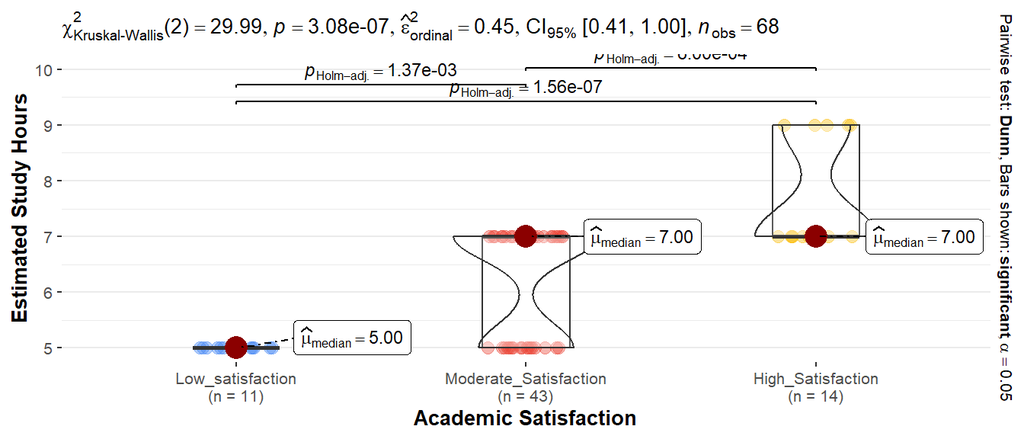

Figure 1: Comparison of study hours by academic satisfaction.

```r
ggbetweenstats(
  data = df,
  x = Academic_Satisfaction,
  y = study_hours_num,
  type = "nonparametric",
  bf.message = FALSE,
  xlab = "Academic Satisfaction",
  ylab = "Estimated Study Hours"
)
```

Based on the plot and the p-value being less than 5% ($p < 0.001$), we reject the null hypothesis. There is strong evidence that estimated study/sleep hours differ significantly when grouped according to academic satisfaction levels. Students reporting higher satisfaction tend to report distinct patterns in their daily rest and study commitments compared to those with lower satisfaction.